# MATH5741M: Statistical Theory and Methods

Benjamin Thorpe

2021-12-05

Benjamin Thorpe (b.thorpe@leeds.ac.uk)  
Sunday December 05, 2021

# Examples

## Week 3

### Example 1

Consider the following realisation of a random sample:
$$\{3, 1, 4, 6, 8, 9, 10, 19, 15\}.$$

1. If we want to learn about the shape of the distribution from which this sample comes (e.g. whether it is normal), what is the best graphical summary for us to use?
   1. Box plot.
   2. Sample CDF.
   3. Histogram.
2. Write down the frequency distribution using the intervals
   $$[0, 5),\; [5, 10),\; [10, 20).$$
3. Plot a “histogram” with frequency on the vertical axis. Might this misrepresent the distribution of the data set? How?
4. Plot a histogram with density on the vertical axis,

### Solution

**Part 1.** A histogram.

**Part 2.** The first step is usually to order the data from smallest to largest:
$$\{1, 3, 4, 6, 8, 9, 10, 15, 19\}.$$

Let $f_1$ be the frequency for the interval $[0, 5)$. What is $f_1$?
$$f_1 = 3.$$
Let $f_2$ be the frequency for the interval $[5, 10)$. What is $f_2$?
$$f_2 = 3.$$
Let $f_3$ be the frequency for the interval $[10, 20)$. What is $f_3$?
$$f_3 = 3.$$

**Part 3.**

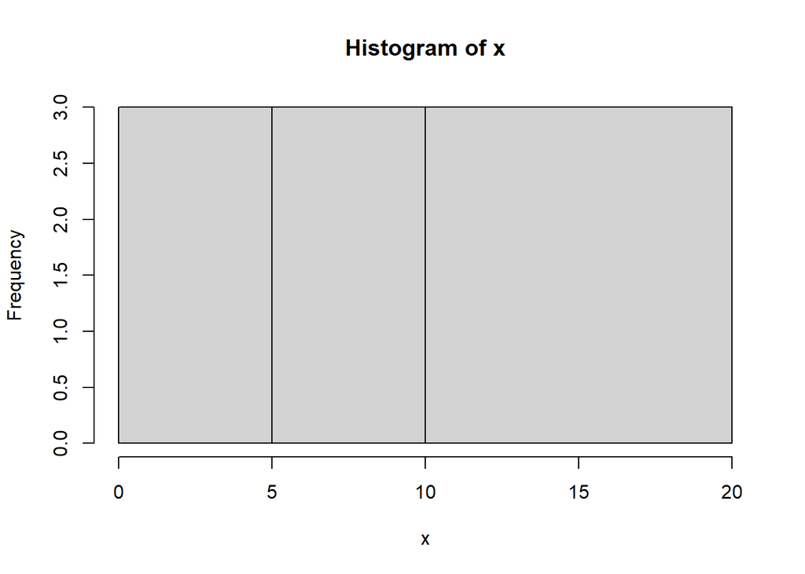

Figure 1: A ‘histogram’ with frequencies on the vertical axis. At first sight, this appears to suggest that the realisations in our sample are roughly uniformly spread from 0 to 20.

```r
x <- c(1,3,4,6,8,9,10,15,19)
hist(x, right = FALSE, breaks = c(0,5,10,20),freq = TRUE)
```

This is not really a histogram because the area of each bars is not proportional to the proportion of our sample represented by each bar. It misrepresents the data in our sample by suggesting that this data is roughly uniformly spread from $0$ to $20$. This is clearly not the case, as we can see just by looking at our sample that the data are more sparse from $10$ to $20$ than they are from $0$ to $10$.

**Part 4.** What is the density for the interval $[0, 5)$?
$$\frac{\text{frequency}/n}{\text{width}} = \frac{3/9}{5} \approx 0.066.$$
What is the density for the interval $[5, 10)$?
$$\frac{\text{frequency}/n}{\text{width}} = \frac{3/9}{5} \approx 0.066.$$
What is the density for the interval $[10, 20)$?
$$\frac{\text{frequency}/n}{\text{width}} = \frac{3/9}{10} \approx 0.033.$$

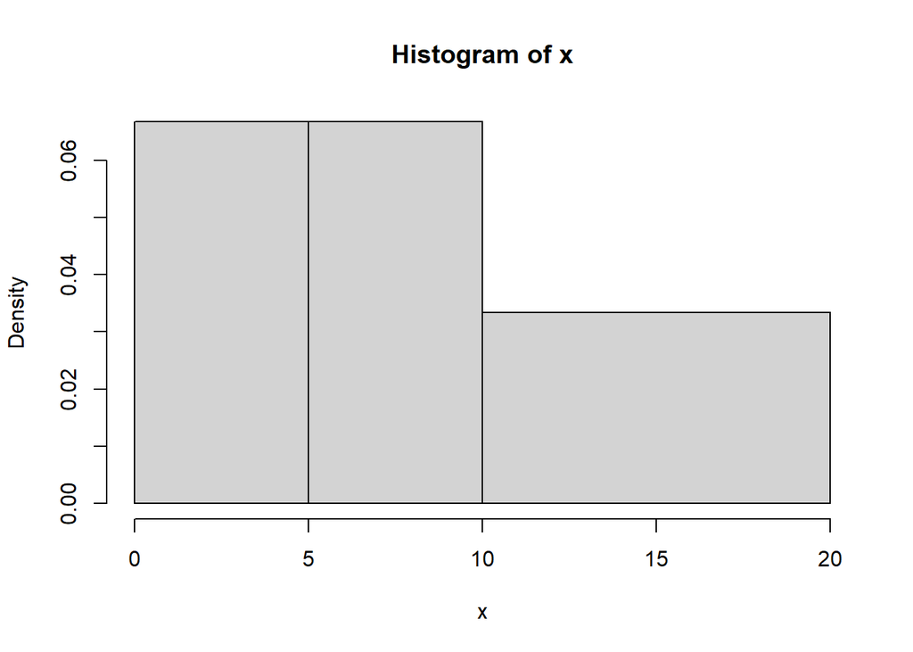

Figure 2: An actual histogram with densities on the vertical axis. This accurately shows the skewed nature of the sample.

```r
hist(x, right = FALSE, breaks = c(0,5,10,20),freq = FALSE)
```

### Example 2

Consider the function
$$f\left( x\right) =\Bigg\{
\begin{array}{ll}
2k e^{- 2 x} & \text{ if } x>0 \\
-Cx^2 & \text{ if } x\leq 0\\
\end{array}$$
where $k > 0$ and $C \geq 0$ are constant parameters.

1. For which values of $C$ can $f(x)$ be a valid density/mass function? Why?
2. If this represents a density/mass function of a random variable $X$, is that variable continuous or discrete?
3. We need to find all values of $k$ for which this gives a valid density function. Which general property of density/mass functions should we use? Find these values of $k$.
4. Which distribution is this? Look in your notes if you need to.

### Solution

**Part 1.** A density/mass function must be **non-negative** for **all** values of $x$, so $C = 0$ is the only option here.

**Part 2.** It’s continuous because the variable can take **any value** in the interval $(0, \infty)$.

**Part 3.** The integral over all of $\mathbb{R} = (-\infty, \infty)$ for a density function must be
$$\int_{-\infty }^{\infty }f(x) dx = {\mathsf P}(X \in (-\infty, \infty)) = 1.$$
With $C = 0$, we know that
$$f\left( x\right) =\Bigg\{
\begin{array}{ll}
2k e^{- 2 x} & \text{ if } x>0 \\
0 & \text{ if } x\leq 0\\
\end{array}$$
where $k > 0$ is a constant parameter. Taking the integral over the entire real line, we get
$$\begin{eqnarray*}
1 & = & \int_{-\infty }^{\infty }f(x) dx\\
& = & \int_{-\infty }^{0}f(x) dx + \int_{0}^{\infty }f(x) dx\\
& = & 0 + \int_{0}^{\infty }2k e^{-2 x} dx\\
& = & 2k \int_{0}^{\infty } e^{-2 x} dx\\
& = & 2k \bigg[ -\frac{1}{2}\,e^{- 2 x} \bigg]_{0}^{\infty} \\
& = & -\frac{1}{2} 2k \bigg[ \left(\frac{1}{e^{x}}\right)^2 \bigg]_{0}^{\infty} \\
& = & -k \bigg[ \left(\frac{1}{e^{\infty}}\right)^2 - \left(\frac{1}{e^{0}}\right)^2 \bigg]\\
& = & -k \bigg[ \left(\frac{1}{\infty}\right)^2 - \left(\frac{1}{1}\right)^2 \bigg]
\;\;\; = \;\;\; -k \bigg[ 0^2 - 1^2 \bigg] \;\;\; = \;\;\; k.
\end{eqnarray*}$$

Therefore $k = 1$ is the only value for which $f(x)$ gives a valid density function.

**Part 4.** Exponential with parameter $\lambda = 2$.

## Week 4

Consider the function
$$f\left( x\right) =\Bigg\{
\begin{array}{ll}
0.4 & \text{ if } x = 1 \\
0.2 & \text{ if } x = 2\\
0.4 & \text{ if } x = 3
\end{array}$$
where and $f(x) = 0$ for all $x \notin \{1, 2, 3\}$.

1. Suppose that this is the density/mass function of a random variable $X$. Is that variable continuous or discrete?
2. What is the probability that $X \in [1,3)$?
3. What is the probability that $X \in (1,3)$?
4. In general (not just for this example), does the expectation ${\mathsf E}(X)$ have to be in the set of possible values for our variable $X$?
5. What is the expectation ${\mathsf E}(X)$?
6. How should we interpret ${\mathsf E}(X)$?
   1. The most likely value of $X$.
   2. The middle value of the distribution, such that $X$ is equally likely to be above or below ${\mathsf E}(X)$.
   3. If we could repeatedly and indefinitely observe values of $X$, then ${\mathsf E}(X)$ would be the long-run average of our observations.
7. What is the variance $\text{var}(X)$?

### Solution

**Part 1.** Discrete, because the set of possible values of $X$ is finite and therefore countable.

**Part 2.**
$$\begin{eqnarray*}
{\mathsf P}(X \in [1,3)) & = & {\mathsf P}(X = 1 \;\;\cup\;\; X = 2)\\
& = & {\mathsf P}(X = 1) + {\mathsf P}(X = 2)
\;\; = \;\; f(1) + f(2)
\;\; = \;\; 0.6.
\end{eqnarray*}$$

**Part 3.**

$$\begin{eqnarray*}
{\mathsf P}(X \in (1,3)) = {\mathsf P}(X = 2) = f(2) = 0.2.
\end{eqnarray*}$$

**Part 4.** No. For example if a variable is binary and only takes values $1$ or $0$, the expectation will be somewhere between $1$ and $0$.

**Part 5.** By definition,
$$\begin{eqnarray*}
{\mathsf E}(X) & = & \sum_{x = 1}^{3}x{\mathsf P}(X = x)\\
& = & \sum_{x = 1}^{3}xf(x)\\
& = & 1\times f(1) + 2\times f(2) + 3\times f(3)\\
& = & 1\times 0.4 + 2\times 0.2 + 3\times 0.4\\
& = & 2.
\end{eqnarray*}$$

**Part 6.** c: as a long-run average.

**Part 7.** We need to calculate ${\mathsf E}(X^2)$ first, so that we can apply the formula
$$\text{var}(X) = {\mathsf E}(X^2) - {\mathsf E}(X)^2.$$
By definition,

$$\begin{eqnarray*}
{\mathsf E}(X^2) & = & \sum_{x = 1}^{3}x^2 f(x).
\end{eqnarray*}$$

But why is this not $\sum_{x = 1}^{3}x^2 f(\boldsymbol{\color{blue}{x^2}})$ instead? Because the expectation of $X^2$ should be

$${\mathsf E}(X^2) = \sum_{x = 1}^{3}x^2 {\color{blue}{{\mathsf P}(X^2 = x^2)}}$$
where, for example, ${\mathsf P}(X^2 = 3^2) = {\mathsf P}(X = 3)$ is $f(3)$ not $f(3^2) = f(9) = 0$.

$$\begin{eqnarray*}
{\mathsf E}(X^2) & = & \sum_{x = 1}^{3}x^2f(x)\\
& = & 1^2\times f(1) + 2^2\times f(2) + 3^2\times f(3)\\
& = & 1^2\times 0.4 + 2^2\times 0.2 + 3^2\times 0.4\\
& = & 4.8. \\
\Rightarrow \quad \text{var}(X) & = & {\mathsf E}(X^2) - {\mathsf E}(X)^2 \;\; =\;\; 4.8 - 2^2 = 0.8.
\end{eqnarray*}$$

## Week 5

Consider a disease with unknown prevalence $\theta \in (0, 1)$. An imperfect diagnostic test for this disease will return a result $X = 1$ (positive) or $X = 0$ (negative) for each patient. The distribution of $X$ has mass function
$$f(x) = \left\{\begin{array}{ll}
0.4 + 0.6\theta & \;\;\textrm{if } x = 1,\\
0.6 - 0.6\theta & \;\;\textrm{if } x = 0.\\
\end{array}\right.$$

1. What is the method of moments (MOM) estimator for $\theta$?
2. Suppose that we observe a sample $\{1,0,0,1\}$. Find the MOM estimator for $\theta$. Can we conclude that this is the true prevalence in the population from which this sample was drawn?
3. What is the maximum likelihood estimator for $\theta$?
4. If the MLE and MOM estimators are the same, does this confirm that they give the correct value of $\theta$?

### Solution

**Part 1.** We set
$$\overline{X} \approx {\mathsf E}(X)$$
and solve for $\theta$. The expectation is
$${\mathsf E}(X) = \sum_{x=0}^{1}xf(x) = 0 + 1 \times (0.4 + 0.6\theta) = 0.4 + 0.6\theta.$$
Therefore we take
$$\overline{X} \approx {\mathsf E}(X) \quad \Leftrightarrow \quad \overline{X} \approx 0.4 + 0.6\theta$$
which simplifies to
$$10\overline{X} \approx 4 + 6\theta \quad \Leftrightarrow \quad \theta \approx \frac{10\overline{X} - 4}{6}.$$

In conclusion, we set
$$\widehat{\theta}_{MOM} = \frac{10\overline{X} - 4}{6}.$$

**Part 2.**

$$\widehat{\theta}_{MOM} = \frac{10\times \frac{1}{2} - 4}{6} = \frac{1}{6}.$$
No, we cannot conclude that
$$\widehat{\theta}_{MOM} = \theta.$$

**Part 3.** In general, we need to consider a hypothetical **observed** sample $x_1, \ldots, x_n$, and how likely this sample is:

$${\mathsf P}(X_1 = x_1 \cap X_2 = x_2 \cap \ldots \cap X_n = x_n) = {\mathsf P}(X_1 = x_1){\mathsf P}(X_2 = x_2)\ldots {\mathsf P}(X_n = x_n).$$
This step assumes **independence** of the observations in our sample (so that we can write the probability above as a product). Note that independence implies zero correlation, but assuming just that the observations are uncorrelated would not have been enough to perform the step above.

Now, using the mass function and the assumption of **identical** distributions:

$${\mathsf P}(X_1 = x_1 \cap X_2 = x_2 \cap \ldots \cap X_n = x_n) = f(x_1)f(x_2)\ldots f(x_n).$$
Suppose that the sample consists of $m$ ones and $n - m$ zeros.
$$f(x_1)f(x_2)\ldots f(x_n) = f(1)^{m}f(0)^{n-m} = (0.4 + 0.6\theta)^{m}(0.6 - 0.6\theta)^{n-m}.$$

As a function of $\theta$, our likelihood is
$$L(\theta) = (0.4 + 0.6\theta)^{m}(0.6 - 0.6\theta)^{n-m}.$$

Our log likelihood is
$$\ell(\theta) = \log L(\theta) = \log\left((0.4 + 0.6\theta)^{m}(0.6 - 0.6\theta)^{n-m}\right).$$

Now we use the rules $\log(AB) = \log(A) + \log(B)$ and $\log A^B = B \log A$:
$$\ell(\theta) = m\log(0.4 + 0.6\theta) + (n - m)\log(0.6 - 0.6\theta).$$

To maximise, we set

$$0 = \frac{d}{d\theta}\ell(\theta) = m\frac{0.6}{0.4 + 0.6\theta} - (n - m)\frac{0.6}{0.6 - 0.6\theta}$$
where we have used the rule $\frac{d}{dx}\log f(x) = \frac{df/dx}{f(x)}.$

This is equivalent to
$$\frac{m}{4 + 6\theta} = \frac{n - m}{6 - 6\theta},$$

which rearranges to
$$6m - 6m\theta = 4n + 6n\theta - 4m - 6m\theta \quad \Leftrightarrow \quad \frac{10m - 4n}{6n} = \theta.$$

But what is $m$? We said it is the number of ones in our sample:
$$m = \sum_{i}x_i = n\left(\frac{1}{n}\sum_{i}x_i\right) = n\overline{x}.$$

Therefore the candidate for our estimate is
$$\widehat{\theta}_{MLE} = \frac{10n\overline{x} - 4n}{6n} = \frac{10\overline{x} - 4}{6}.$$

The estimat**or** (of which our estima**te** is a single realisation) would be
$$\widehat{\theta}_{MLE} = \frac{10\overline{X} - 4}{6}.$$

How can we check that this gives a maximum? Check that
$$d^2\ell/d\theta^2 < 0$$
at $\theta = \widehat{\theta}_{MLE}$.

**Part 4.** No. Both estimators can give estimates that are wrong. The fact that they are equal just means that they will be equally wrong.

## Week 6

Recall the mass function from last week,
$$f(x) = \left\{\begin{array}{ll}
0.4 + 0.6\theta & \;\;\textrm{if } x = 1,\\
0.6 - 0.6\theta & \;\;\textrm{if } x = 0,\\
\end{array}\right.$$
where $X$ is the result of a diagnostic test ($X=1$ for a positive test, $X = 0$ for a negative test) for a disease with prevalence $\theta$. Last week we showed that the expectation is
$${\mathsf E}(X) = \sum_{x=0}^{1}xf(x) = 0.4 + 0.6\theta$$
and the MOM and MLE estimators are both
$$\widehat{\theta} = \frac{10\overline{X} - 4}{6}.$$

1. What does it mean for an estimator $\widehat{\theta}$ of $\theta$ to be unbiased?
   1. $\widehat{\theta}$ is the best possible estimator of $\theta$.
   2. $\widehat{\theta}$ will not, on average, overestimate or underestimate $\theta$.
   3. $\widehat{\theta}$ is equal to $\theta$ more often than not.
2. How can we show that $\widehat{\theta}$ is unbiased?
   1. Observe many samples and check if $\widehat{\theta} = \theta$ each time.
   2. Find **some** value of $\theta$ such that ${\mathsf E}(\widehat{\theta}) = \theta$.
   3. Show that ${\mathsf E}(\widehat{\theta}) = \theta$ for **all** possible values of $\theta$.
3. Is $\widehat{\theta}$ an unbiased estimator of $\theta$?
4. What is the MSE of $\widehat{\theta}$? What happens to the MSE as we increase $n$?
5. What is the sampling distribution of $\widehat{\theta}$?
   1. An exact normal distribution for large $n$.
   2. Approximately a normal distribution for any $n$.
   3. Approximately a normal distribution for large $n$.
   4. Something else.

### Solution

**Part 1.** b.

**Part 2.** c.

**Part 3.**
$$\begin{eqnarray*}
{\mathsf E}(\widehat{\theta}) & = & {\mathsf E}\left(\frac{10\overline{X} - 4}{6}\right)\\
& = & {\mathsf E}\left(\frac{10}{6}\overline{X} + \frac{-4}{6}\right)\\
& \stackrel{{\color{blue}{\text{linearity}}}}{=} & \frac{10}{6}{\mathsf E}\left(\overline{X}\right) + \frac{-4}{6}\\
& = & \frac{10}{6}{\mathsf E}\left(\frac{1}{n}\sum_{i=1}^{n}X_i\right) - \frac{4}{6}\\
& \stackrel{{\color{blue}{\text{linearity}}}}{=} & \frac{10}{6}\frac{1}{n}{\mathsf E}\left(\sum_{i=1}^{n}X_i\right) - \frac{4}{6}
\end{eqnarray*}$$
and here we can use the fact that the expectation of a sum is equal to the sum of the expectations to get
$$\begin{eqnarray*}
{\mathsf E}(\widehat{\theta}) & \stackrel{{\color{blue}{{\mathsf E}(\sum X_i) = \sum {\mathsf E}(X_i)}}}{=} & \frac{10}{6n}\sum_{i=1}^{n}E(X_i) - \frac{4}{6}\\
& \stackrel{{\color{blue}{{\mathsf E}(X) = 0.4 + 0.6\theta }}}{=} & \frac{10}{6n}\sum_{i=1}^{n}(0.4 + 0.6\theta) - \frac{4}{6}\\
& = & \frac{10}{6n}\underbrace{\bigg[(0.4 + 0.6\theta) + \ldots + (0.4 + 0.6\theta)\bigg]}_{\text{n times}} - \frac{4}{6}\\
& = & \frac{10}{6n}n(0.4 + 0.6\theta) - \frac{4}{6}\\
& = & \frac{4 + 6\theta}{6} - \frac{4}{6}
\quad = \quad \theta
\qquad \Rightarrow \qquad \text{bias}(\widehat{\theta}) = 0.
\end{eqnarray*}$$

**Part 4.** First we need the variance:
$$\begin{eqnarray*}
\text{var}(X) & = & {\mathsf E}(X^2) - {\mathsf E}(X)^2\\
& = & \sum_{x=0}^{1}x^2f(x) - {\mathsf E}(X)^2\\
& = & 0^2(0.6 - 0.6\theta) + 1^2(0.4 + 0.6\theta) - {\mathsf E}(X)^2\\
& \stackrel{{\color{blue}{ {\mathsf E}(X) = 0.4 + 0.6\theta}}}{=}& (0.4 + 0.6\theta) - (0.4 + 0.6\theta)^2\\
& = & (0.4 + 0.6\theta)\left[1 - (0.4 + 0.6\theta)\right]\\
& = & (0.4 + 0.6\theta)\left[0.6 - 0.6\theta\right]\\
& = & \frac{(4 + 6\theta)(6 - 6\theta)}{100}
\end{eqnarray*}$$
Given that the bias is $0$ and
$$\begin{eqnarray*}
\text{var}(X) & = & \frac{(4 + 6\theta)(6 - 6\theta)}{100}
\end{eqnarray*}$$
can we say
$$\text{MSE} = \text{variance} + \text{bias}^2 = \frac{(4 + 6\theta)(6 - 6\theta)}{100} + 0\;?$$
No, we can’t. Remember that
$$\text{MSE} = \text{var}(\widehat{\theta}) + \text{bias}(\widehat{\theta})^2.$$
We have
$$\begin{eqnarray*}
\text{var}(\widehat{\theta}) & = & \text{var}\left(\frac{10}{6}\overline{X} - \frac{4}{6}\right)\\
& \stackrel{{\color{blue}{\text{var}(aY + b) = a^2\text{var}(Y)}}}{=} & \frac{100}{36}\text{var}\left(\overline{X}\right)
\end{eqnarray*}$$
and therefore
$$\begin{eqnarray*}
\text{MSE} \;\;\;\; = \;\;\;\; \text{var}(\widehat{\theta}) + \text{bias}(\widehat{\theta})^2
& = & \frac{100}{36}\text{var}\left(\overline{X}\right) + 0^2\\
& = & \frac{100}{36}\text{var}\left(\frac{1}{n}\sum_{i=1}^{n}X_i\right)\\
& = & \frac{100}{36}\frac{1}{n^2}\text{var}\left(\sum_{i=1}^{n}X_i\right)\\
& \stackrel{{\color{blue}{\text{independence}}}}{=}& \frac{100}{36}\frac{1}{n^2}\sum_{i=1}^{n}\text{var}\left(X_i\right)\\
& = & \frac{100}{36}\frac{1}{n^2}\sum_{i=1}^{n}\frac{(4 + 6\theta)(6 - 6\theta)}{100}\\
& = & \frac{100}{36}\frac{1}{n^2}\times n\times\frac{(4 + 6\theta)(6 - 6\theta)}{100}\\
& = & \frac{1}{36n}(4 + 6\theta)(6 - 6\theta). % \rightarrow 0 \text{ as } n \rightarrow \infty\\
\end{eqnarray*}$$
The MSE decreases as $n$ increases. We can make the MSE as small as we like, as long as we take the sample size to be large enough.

**Part 5.** By the CLT, $\overline{X}$ is approximately normally distributed if $n$ is large. If $\overline{X}$ is normally distributed, then so is $a\overline{X} + b$ whenever $a$ and $b$ are constant. Therefore,
$$\widehat{\theta} \quad = \quad \frac{10}{6}\overline{X} - \frac{4}{6}
\qquad \stackrel{approx.}{\sim} \qquad N\left( \theta, \quad \frac{1}{36n}(4 + 6\theta)(6 - 6\theta) \right).$$
Therefore the answer is c, approximately normal for large $n$.

## Week 7

Animal welfare requirements state that buildings in which piglets are kept should maintain a temperature such that the mean is $20$ degrees Celsius. A farm suspected of violating this rule was inspected on eleven random occasions and the temperatures recorded:
$$10,\;\; 10,\;\; 11,\;\; 12,\;\; 13,\;\; 14,\;\; 19,\;\; 20,\;\; 27,\;\; 28,\;\; 34.$$
The farm owner will be investigated for animal cruelty if these data lead to the conclusion that mean temperature is not equal to $20$. A z-test (based on the CLT) will be used to decide whether the farmer should be investigated or not.

1. Let $\mu$ be the true population mean for the temperatures. What are our hypotheses?
   1. $H_0: \overline{x} = 20$ and $H_1:\overline{x} \neq 20$.
   2. $H_0: \mu = \overline{x}\,\,\,$ and $H_1:\mu \neq \overline{x}$.
   3. $H_0: \mu = 20$ and $H_1:\mu \neq 20$.
   4. $H_0: \mu \neq 20$ and $H_1:\mu = 20$.
2. What is a type I error in this example? What are the consequences?
3. What is a type II error in this example? What are the consequences?
4. If we test $H_0$ with significance level $5\%$, what does this achieve?
   1. We have a $95\%$ probability of coming to the correct conclusion.
   2. The probability of a type II error will be $\leq 5\%$.
   3. The probability of a type I error will be $\leq 5\%$.
5. Test your hypotheses by calculating a $95\%$-confidence interval in R or by hand.
6. What should we conclude about the null hypothesis? What kind of error is this?
   1. Type I error.
   2. Type II error.
   3. Not an error.
   4. We can’t say.
7. Calculate the p-value for your test.
8. At which significance level can we say we reject the null?
   1. $5\%$
   2. $21.330675\%$
   3. $45\%$
9. Make a box plot of the observed sample.
10. What are your criticisms of this analysis and of this approach to investigating animal welfare?

### Solution

**Part 1.** $H_0: \mu = 20$ and $H_1:\mu \neq 20$. We assume the owner is innocent unless the evidence indicates otherwise.

**Part 2.** Rejection of a true null hypothesis (concluding the mean temperature is different to $20$, when it actually is $20$). This would lead to a potentially unnecessary investigation of animal cruelty.

**Part 3.** Failure to reject a false null hypothesis (concluding the mean temperature is $20$, when it is actually not $20$). This might lead to a case of animal cruelty not being investigated.

**Part 4.** The probability of a type I error will be $\leq 5\%$.

**Part 5.** The formula for our CI is:
$$\left(\overline{X} - z_{\alpha/2} \sqrt{\frac{\sigma^2}{n}} \;\;, \;\; \overline{X} + z_{\alpha/2}\sqrt{\frac{\sigma^2 }{n}} \right).$$

```r
x <- c(10, 10, 11, 12, 13, 14, 19, 20, 27, 28, 34)

# Estimate sigma:

s <- sd(x)

s
```

```
## [1] 8.342661
```

```r
alpha <- 0.05

n <- length(x)

xbar <- mean(x)

xbar
```

```
## [1] 18
```

```r
# 97.5% quantile:

z_0.025 <- qnorm(1 - alpha/2, mean = 0, sd = 1)

# Let's check this is the same as in the tables:

z_0.025
```

```
## [1] 1.959964
```

```r
# Confidence interval:

CI <- c( xbar - z_0.025 * sqrt(s^2/n), xbar + z_0.025 * sqrt(s^2/n) )

CI
```

```
## [1] 13.06989 22.93011
```

**Part 6.** Fail to reject $H_0: \mu = 20$ at the $5\%$ significance level because $20$ is inside the interval. We can’t say if this is an error or not because we don’t know the true value of $\mu$. It **could** be a Type II error, but definitely not Type I.

**Part 7.** For a z-test, our observed test statistic is
$$z = \frac{\overline{x} - \mu_0}{\sqrt{\frac{\sigma^2}{n}}}$$

```r
z = (xbar - 20)/sqrt(s^2/n)

z
```

```
## [1] -0.7950999
```

The p-value is then
$${\mathsf P}(|Z| > |-0.795|)$$
for $Z \sim N(0,1)$, so we calculate
$$\begin{eqnarray*}
{\mathsf P}(|Z| > 0.795) & = & {\mathsf P}(Z > 0.795 \;\;\cup\;\; Z < -0.795) \\
& = & {\mathsf P}(Z > 0.795) + {\mathsf P}(Z < -0.795) \\
& \stackrel{\color{blue}{\text{symmetry}}}{=} & 2 \times {\mathsf P}(Z < -0.795) \\
& = & 2\times {\Phi}(-0.795)
\end{eqnarray*}$$

```r
p <- 2 * pnorm(-0.795 , mean = 0, sd = 1)

p
```

```
## [1] 0.4266135
```

**Part 8.** We can reject the null at the $45\%$ level, the $44\%$ level, the $43\%$, and at any other level greater than the p-value. We cannot reject at any level less than the p-value.

**Part 9.**

```r
quantile(x, type = 1)
```

```
##   0%  25%  50%  75% 100%
##   10   11   14   27   34
```

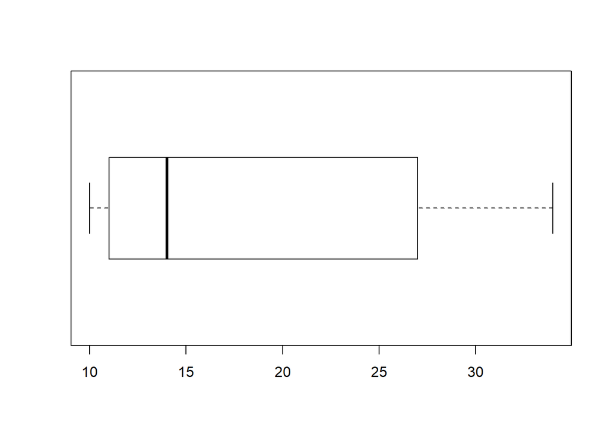

Figure 3: A boxplot showing temperatures with a large spread and a strong skew.

```r
library("qboxplot")

qboxplot(x = data.frame(x), horizontal = TRUE, qtype = 1)
```

**Part 10.** Testing whether the mean is $20$ does not make sense in terms of animal welfare, given that a mean of $20$ can be achieved even with a very large spread in temperatures. Also, the CLT might not work well here because of the combination of both the data appearing to be very skewed and the sample size being small (just one of these issues alone would probably not be a concern). Furthermore, we only have an estimate of the population variance based on a small sample size, but the z-test assumes the population variance to be known (again, this would not be a major concern if the sample size was large and we could therefore trust $s^2$ to give a good estimate of $\sigma^2$).

## Week 8

Consider a standard maths exam that is taken by every new student at a university. The exam is the same for all students and has been the same for many years. Thus, it has been taken by thousands of students. Based on this past data, we are thoroughly convinced that the probability distribution of student scores ($X$) on this exam is normal:
$$X \sim N(50, 5^2).$$

1. For the 2020 cohort the university has been caught inflating the marks on this exam, but they have not admitted how much they have inflated the results by. They are accused of adding $5$ points to every student’s mark. To investigate, we will denote the population mean exam mark at this university **in 2020** by $\mu$ and we will test the hypotheses
   $$H_0: \mu = 55 \qquad \text{vs.} \qquad H_1: \mu \neq 55$$
   using the marks of a random sample of $n = 10$ students from the 2020 cohort. We assume that no inflation occurred in previous years and that any inflation of marks for the 2020 cohort was consistent across all students. Should we use a t-test or a z-test?
2. To investigate further, we want to test whether the **actual** student marks in 2020 (i.e. without university interference) would have been different to the marks in previous years. We let $\theta$ denote the hypothetical **actual** population mean for 2020 students. To test if this is different to previous years (where the population mean was $50$), we will test the hypotheses
   $$H_0: \theta = 50 \qquad \text{vs.} \qquad H_1: \theta \neq 50.$$
   To achieve this we have taken a sample of $n = 15$ random 2020 students, have given them the exam under our supervision outside the university, and have marked their scripts fairly and without inflation. This sample of marks can then be considered to come from a distribution with population mean $\theta$. Furthermore, before testing $H_0$, we note that the normal QQ plot for the marks of these students is close to a straight line. Which test should we use?
3. To assess the need for additional maths support in social sciences programmes, a random sample of size $n = 300$ students from these programmes will take the exam under our supervision (to prevent inflation). We would like to test if their population mean score (denoted $\gamma$) is different to that of the rest of the university (still assumed to be $50$ without inflation). We will therefore test
   $$H_0: \gamma = 50 \qquad \text{vs.} \qquad H_1: \gamma \neq 50.$$
   Previous experience suggests that the maths ability of social sciences students is very varied and very skewed. Which test should we use?
4. Upon observing the the data, a $95\%$-confidence interval for $\gamma$ is calculated to be $(58, 62)$. What is our conclusion? Should the social sciences students receive extra maths support?

### Solution

**Part 1.** If the inflation was consistent across all students then we know the variance (remember $\text{var}(X + constant) = \text{var}(X)$ for any variable $X$), which should be $25$, the same as previous years. Therefore a z-test seems sensible. We don’t have to worry about the sample size because our sample can be assumed to be from a normal distribution (remember if $X$ is normal then so is $X + constant$) and therefore we can assume $\overline{X}$ is normal and hence so is our test statistic $Z$. The CLT approximation is not needed, so we don’t need the sample size to be large.

**Note.** We could have used a t-test here too (the necessary assumptions are satisfied). However, a t-test might be unnecessarily cautious because it assumes the population variance is not known and therefore uses the sample variance. If the population variance is known, then it’s preferable to take advantage of that by applying the z-test.

**Part 2.** A t-test seems to be the obvious choice. If the 2020 cohort might be genuinely different to students from previous years then we can’t necessarily assume that the variance remains the same. Therefore the population variance for 2020 students is not necessarily known, so a z-test might not be appropriate. Also, the normality assumption required for a t-test is supported by the QQ plot.

**Part 3.** The z-test appears to be the only option here because the CLT tells us that, thanks to the large sample size, the $Z$ statistic will be approximately normal despite the potentially skewed distribution of the sample. We don’t need to worry about the unknown variance because the large sample size allows us to reasonably assume the population variance for social scientists is equal to the sample variance $s^2$ (which is not an ideal assumption, but usually works well enough). We probably should not assume the population variance (for the **population of social sciences students**) to be $25$ because of the comment that these students are “very varied”, suggesting a larger spread than we would expect in ordinary students.

**Part 4.** Reject $H_0: \gamma = 50$. These students do not appear to need additional support because the confidence interval is entirely above $50$, suggesting that the plausible values for $\gamma$ (according to our data) are above the mean exam mark for ordinary university students. In other words, social sciences students tend to perform better in maths than other students and therefore don’t need extra help **on average**. But this does not mean that there are no **individual** social sciences students who might require extra help (remember the comments about the large spread and skew).

## Week 8 extra comment (CLT, z-tests and sample size)

There was a question asked this week: **“If I want to use the CLT to perform a z-test, how big does my sample have to be?”**

The CLT works perfectly at any sample size if your data are from a normal distribution. Usually, data that appear to be “less normal” will require a bigger sample size for the CLT to be useful. So if your data show an extreme skew, then you will need a “large” sample size. But the CLT works surprisingly well, so you might not need a sample as large as you think.

For example, consider the data below:

```r
x <- c(1, 2, 26, 26, 68, 81, 104, 113, 247, 544)

hist(x)
```

[output not shown]

These show a strong skew. Taking `1/mean(x)` suggests that they might come from an exponential distribution $Exp(0.008)$. If we really are sampling from this highly skewed distribution, is the sample large enough that we can assume the sample mean (and thus the $Z$ statistic) will be approximately normally distributed? We can simulate $100$ samples of size $n = 10$ from this distribution to check:

```r
samplemeans <- rep(NA, 100)   # An empty vector to store our 100 sample means.

for(i in 1:100){

  n <- 10

  simulatedsample <- rexp(n, 0.008)  # Sample of size n = 10 from Exp(0.08).

  samplemeans[i] <- mean(simulatedsample) # Store the i-th sample mean.

}

# Check if our sample means are normally distributed:

qqnorm(samplemeans)
```

[output not shown]

We see that, even with a skewed distribution **for the samples**, the QQ plot seems to confirm that the **sample means** are approximately normally distributed. This means that the CLT is working impressively well, even with a sample size as small as $n =10$. But what if $n = 5$? Let’s run our simulations with $n = 5$ to find out:

```r
samplemeans <- rep(NA, 100)

for(i in 1:100){

  n <- 5

  simulatedsample <- rexp(n, 0.008)

  samplemeans[i] <- mean(simulatedsample)

}

qqnorm(samplemeans)
```

[output not shown]

It still looks pretty normal. Not as normal as when we had $n = 10$, but that’s not surprising.

To get a general feel for how well the CLT work, you can play around with these simulations for different sample sizes $n$ and different parameters for the exponential distribution (other than $0.008$).

In summary, you don’t need a gigantic sample to apply the CLT. If you are unsure about whether you trust the CLT for your own analysis, you can perform the simulations above, just with $n$ replaced by your own sample size and with $Exp(0.008)$ replaced by a distribution that is reasonably close to the distribution of your sample. If the QQ plot of your simulated sample means is close to a straight line, then applying the CLT should be safe.

However, you **don’t** need to include these simulations in your coursework report, and please remember that if you are choosing between a t-test and a z-test then you still need to consider whether you are willing to assume the population variance is known.

## Week 9

Consider a learning disability that negatively affects geometrical reasoning skills. Suppose that $50\%$ of English secondary school students have this mild disability.

1. Suppose that we select a secondary school student at random. Consider the variable
   $$D = \begin{cases} 1 & \text{if the student has the disabilty,} \\ 0 & \text{if the student does not have the disability.} \end{cases}$$
   What is the probability distribution of $D$? Write down and simplify its mass function.
2. A computer program had been developed that can generate sequences of short, random geometry exercises. For any question generated by this program, the probability of the student giving the wrong answer is
   $$\displaystyle \frac{1 + D}{10}.$$
   That is, $10\%$ for students without the disability and $20\%$ for those with. Suppose that a student will be assessed by repeatedly answering questions until they get one wrong. Let $Y$ be the number of correct answers. What is the conditional distribution of $Y$ given $D = d$? Write down the (conditional) mass function.
3. What is $f(y)$, the (marginal) mass function of $Y$ when we don’t know $D$? Plot this mass function in R.
4. Once we observe a student’s number of correct answers, how can we use that to assess the probability that the student has the disability? Plot a graph in R to illustrate your answer.

### Solution

**Part 1.** $D \sim \text{Bin}(1, 0.5)$, with mass function
$$f(d) = {\mathsf P}(D = d) = 0.5^{d}(1-0.5)^{1-d} = 0.5.$$

**Part 2.** $Y \mid D = d \sim \text{Geom}([1+d]/10)$, with mass function
$$f(y\mid d) = {\mathsf P}(Y = y \mid D = d) = \left(1-\frac{1+d}{10}\right)^{y}\frac{1+d}{10}.$$

**Part 3.** We can partition the population into $\{D = 1\}$ and $\{D = 0\}$. By partition theorem,
$$\begin{eqnarray*}
f(y) = {\mathsf P}(Y=y) & = & \sum_d {\mathsf P}(Y=y \mid D = d){\mathsf P}(D = d) \\
& = & \sum_{d=0}^{1} f(y\mid d) f(d)\\
& = & \left(1-\frac{1}{10}\right)^{y}\frac{1}{10}0.5 +
\left(1-\frac{2}{10}\right)^{y}\frac{2}{10}0.5\\
& = & \frac{1}{20}\left(0.9^{y} + 2 \times 0.8^{y}\right).
\end{eqnarray*}$$

```r
f = function(y){
         return( ( 0.9^y + 2*(0.8^y) )/20 )
}

y <- 0:40

plot(y, f(y), pch = 16, col = "blue")
```

[output not shown]

**Part 4.** We want ${\mathsf P}(D = d \mid Y = y)$. But we have ${\mathsf P}(Y = y \mid D = d)$, so we apply Bayes’ theorem (${\mathsf P}(B \mid A) = {{\mathsf P}(A \mid B){\mathsf P}(B)/{\mathsf P}(A)}$) to switch the order of the events in our conditional probability.
$$\begin{eqnarray*}
f(d \mid y) = {\mathsf P}(D = d \mid Y = y) & = &
\frac{{\mathsf P}(Y = y \mid D = d){\mathsf P}(D = d)}{{\mathsf P}(Y = y)}\\
& = & \frac{f(y\mid d)f(d)}{f(y)}\\
& = & \frac{\left(1-\frac{1+d}{10}\right)^{y}(1+d)}{\left(0.9^{y} + 2 \times 0.8^{y}\right).}
\end{eqnarray*}$$

```r
f_dy = function(d, y){

  return( ((0.9-d/10)^y)*(1 + d)/(0.9^y + 2*(0.8)^y) )
}

plot(y, f_dy(0, y), pch = 16, col = "blue", ylim = 0:1, ylab = "probability")

points(y, f_dy(1, y), pch = 16, col = "red")
```

[output not shown]

The red points give the probability of having the disability, given that students answers $y$ problems correctly. The blue points give the probability of **not** having the disability, given that students answers $y$ problems correctly.

## Week 10

Clinical trials of medical treatments each have two possible outcomes:

- positive (the treatment is shown to be effective),
- negative (the treatment is not shown to be effective).

To determine the unknown proportion $p\in (0,1)$ of positive trials, $1000$ randomly selected, independent clinical trials were reviewed. Let the random variable $X$ be the total number of positive trials out of $1000$ independent, randomly selected trials.

1. What is the distribution of $X$?
2. Among the $n = 1000$ reviewed trials, $x = 250$ had a positive result. What is the maximum likelihood estimate of $p$?
3. What is meant by the term “posterior distribution”?
   1. The sampling distribution of our maximum likelihood estimator, $\widehat{p}$.
   2. The estimated distribution of our variable, $X \sim \text{Bin}(n, \widehat{p})$, obtained from our estimate $\widehat{p}$.
   3. The distribution that describes our subjective uncertainty about $p$ after observing our sample.
   4. Two of the above are equivalent.
   5. None of the above are correct.
4. Suppose that **my** beliefs about $p$, before observing $X$, are represented by a prior distribution $p \sim \textrm{Beta}(500, 500)$. Plot the density of this prior in R and interpret my prior beliefs in plain English.
5. Given that we observed $X = 250$, how should my prior beliefs be updated? Write down my posterior distribution for $p$ and plot the density of this distribution in R. Interpret my posterior beliefs in plain English.

### Solution

**Part 1.** $\text{Bin}(1000, p)$. Remember: the binomial distribution models the number of successes in $n$ independent trials, where each trial has probability of success $p$.

**Part 2.** The mass function of a binomial distribution is

$$f(x) = {n\choose x}p^{x}(1-p)^{n-x}.$$

Setting $n = 1000$ and $x = 250$, the likelihood of the single observation $x=250$ is a function of $p$:
$$L(p) = f(250)= {1000 \choose 250}p^{250}(1-p)^{750}$$
and the log likelihood is
$$\begin{eqnarray*}
\ell(p) = \log L(p)
& = & \log{1000 \choose 250} + \log p^{250} + \log(1-p)^{750}\\
& = & \log{1000 \choose 250} + 250\log p + 750\log(1-p).
\end{eqnarray*}$$

Now let’s find the maximum likelihood estimate of $p$.

$$\frac{d\ell}{dp} = 250\frac{1}{p} - 750\frac{1}{1-p}.$$
Setting this equal to zero,
$$\frac{d\ell}{dp} = 0 \quad \Leftrightarrow \quad 250(1-p) = 750p \quad \Leftrightarrow \quad 250 = 1000p \quad \Leftrightarrow \quad p=0.25$$
and therefore $\widehat{p} = 0.25$ is our proposed estimate.

$$\frac{d^2 \ell}{dp^2} = -\frac{250}{p^2} - \frac{750}{(1-p)^2} = -5333 < 0 \quad \text{when } p=0.25$$

which confirms that $\widehat{p} = 0.25$ is a **maximum** likelihood estimate (we also notice that $L(p) \rightarrow 0$ as $p\rightarrow 0$ or $1$, so we know $p = 0.25$ gives a global maximum, not just a local maximum).

**Part 3.** The distribution that describes our subjective uncertainty about $p$ after observing our sample. When we apply Bayesian methods, we move away from ideas such as maximum likelihood estimation. In a Bayesian context, we are not usually thinking about an estimator $\widehat{p}$. Instead, we think of $p$ itself as being random.

**Part 4.** The necessary code is:

```r
p <- seq(from = 0, to = 1, by = 0.01)

prior <- dbeta(p, shape1 = 500, shape2 = 500)

plot(p, prior, type = "l", col = "blue", lwd = 2, ylab = "density")
```

[output not shown]

This suggests that I believe $p$ is very likely to be close to $0.5$, and that I believe there is almost zero probability of $p$ being outside the interval $[0.4, 0.6]$.

**Part 5.** The prior distribution has a density function

$$f(p) \propto p^{\alpha-1}(1-p)^{\beta-1} = p^{499}(1-p)^{499}.$$
The likelihood of $x = 250$ is

$$f(x \mid p) = L(p) = {1000 \choose 250}p^{250}(1-p)^{750} \propto p^{250}(1-p)^{750}.$$
By Bayes’ theorem (posterior $\propto$ prior $\times$ likelihood):
$$\begin{eqnarray*}
f(p \mid x) \propto f(p)f(x \mid p) & \propto & p^{499}(1-p)^{499} \times p^{250}(1-p)^{750}\\
& = & p^{749}(1-p)^{1249}\\
& = & p^{750-1}(1-p)^{1250-1}
\end{eqnarray*}$$
which is proportional to the density of $\textrm{Beta}(750, 1250)$. Since proportionality of density functions implies that they must be equal, this means that my posterior distribution for $p$ must be
$$p \mid X = 250 \quad \sim \quad \textrm{Beta}(750,1250).$$

```r
p <- (0:100)/100
prior <- dbeta(p, shape1 = 500, shape2 = 500)
plot(p, prior, type = "l", col = "blue", lwd = 2, ylab = "density", ylim = c(0, 35))

posterior <- dbeta(p, shape1 = 750, shape2 = 1250)

lines(p, posterior, col = "red3", lwd = 2)
```

[output not shown]

This suggests that my posterior beliefs (sensibly) fall somewhere between my prior beliefs ($p\approx 0.5$) and the conclusion suggested by the data ($p \approx 0.25$). The posterior density appears to suggest that $p$ is very likely to be around $0.37$.

## Week 11 (revision)

### Problem 1

Suppose that for events $A$ and $B$ we are given ${\mathsf P}(B^c)=0.4$ and ${\mathsf P}(A\mid B)=0.3$. What is ${\mathsf P}(B\cap A)$?

### Problem 2

What does the sample median measure?

1. Spread.
2. Location.
3. Skew.

Which graphical summary can we look at to find **all** of the sample quantiles?

1. Box plot.
2. Histogram.
3. Sample cumulative distribution function.

What does the sample correlation measure?

1. Linearity of our sample.
2. Strength of linear association between two **independent** samples.
3. Strength of linear association between two **paired** samples.

You see that your family has given you $n$ wrapped Christmas presents. Let $X$ denote the number of these that will turn out to be socks or cheap toiletries. Which distribution can be used to model $X$?

1. Geometric distribution.
2. Binomial distribution.
3. Normal distribution.

Let $X_1, X_2, \ldots, X_n$ be a large, independent, identically distributed random sample. What does the central limit theorem **not** tell us?

1. The sample mean $\overline{X}$ is approximately normally distributed.
2. The observations $X_i$ are approximately normally distributed.
3. The sum $\sum_{i=1}^{n}X_i$ is approximately normally distributed.

### Problem 3

Professor Spengler has been accused of setting exams that don’t accurately assess students. For comparison, Dr Venkman set an exam on the same topic. Five random students took both exams.

| Student ($i$) | Marks in Venkman’s exam ($x_{i}$) | Marks in Spengler’s exam ($y_{i}$) |
| --- | --- | --- |
| 1 | 65 | 45 |
| 2 | 50 | 35 |
| 3 | 40 | 35 |
| 4 | 60 | 40 |
| 5 | 60 | 45 |

The sample means are $\overline{x} = 55$ and $\overline{y} = 40$, and sample variances are $s_{x}^2 = 100$ and $s_{y}^2 = 25$.

1. What does the calculation
   $$\frac{\sum_{i=1}^{n}(x_i-\overline{x})(y_{i} - \overline{y})}{(n-1)s_x s_y} = \frac{10\times5 + 5\times 5 + 15 \times 5 + 0 + 5\times 5}{4 \times 10 \times 5} = 0.875$$
   give us? How should we interpret this?
2. We want to perform a t-test in R to compare the two exams. Which of the tests below is the right choice? What is the significance level here?

```r
x <- c(65 , 50 , 40 , 60 , 60)
y <- c(45 , 35 , 35 , 40 , 45)

t.test(x, y, paired=FALSE, conf.level=0.9)   # test 1

t.test(x, y, paired=TRUE, conf.level=0.9)    # test 2

t.test(c(x, y), conf.level=0.9)              # test 3
```

3. By hand calculate a $90\%$ confidence interval for the **population** mean difference between scores on the two exams. Should our interval be based on a t-test or a z-test? After calculating the interval what do you conclude?
4. What have we assumed in our test?
5. What type of error might we be making?
6. Suppose that the experiment had been conducted differently: $30$ students randomly selected, with $15$ taking Venkman’s exam and $15$ taking Spengler’s exam. Without doing further calculations, describe how your **analysis and assumptions** would be different.

### Problem 4

Let $\{x_{1}, x_{2}, \ldots, x_{n}\}$ be an independent and identically distributed sample from a distribution with parameter $\beta >0$ and density function
$$f(x) = \beta(1-x)^{\beta-1} \;\;\;\;\textrm{for } x \in (0,1).$$
What is the maximum likelihood estimate of $\beta$?

### Problem 5

Suppose that $X\sim N(4,2^2)$ and, independently, $Y\sim N(2,2^2)$. What are the expectation and variance of $3X + Y$? What is the distribution of $3X+Y$?

### Problem 6

Suppose that the random variable $X$ has a t distribution with $5$ degrees of freedom. If $a >0$ and ${\mathsf P}(X \in [-a, a]) = 80\%$, what is $a$?

### Solution 1

Recall the definition of conditional probability:
$${\mathsf P}(A \mid B) = \frac{{\mathsf P}(A \cap B)}{{\mathsf P}(B)}$$
We know that
$${\mathsf P}(B) = 1-{\mathsf P}(B^c) = 0.6$$
and rearranging the expression above gives
$${\mathsf P}(A \cap B) = {\mathsf P}(A\mid B)\times {\mathsf P}(B) = 0.3 \times 0.6 = 0.18.$$

### Solution 2

The answers are b, c, c, b and b (respectively). For the last question, remember that $\sum_{i=1}^{n}X_i = n\overline{X}$ and if $\overline{X}$ is normal then so is $n\overline{X}$.

### Solution 3

1. The sample correlation. It tells us that there appears to be a strong, positive, linear association between the scores on each exam. So Spengler’s exam is at least able to differentiate the strong students from the weak students.
2. Test 2 is correct. We have paired data. The significance level is $10\%$ ($1 -$ the confidence level).
3. Probably a t-test, since the sample size is small and we don’t know the population variance. The differences are $d_{i}$: $\{20, 15, 5, 20, 15\}$. The **sample** mean difference (Venkman-Spengler) is $\overline{d} = 15$.
   $$s^2 = \frac{1}{4}\sum_{i=1}^{5}(d_{i} - 15)^2 = \frac{5^2 + 0 + 10^2 + 5^2 + 0}{4} = \frac{150}{4} = 37.5.$$
   The degrees of freedom are $\nu = n - 1 = 4$, and thus our confidence interval is
   $$\overline{d} \pm t_{4}(0.1/2)\frac{s}{\sqrt{n}} = 15 \pm t_{4}(0.05)\frac{\sqrt{37.5}}{\sqrt{5}}.$$
   From the statistical tables, $t_{4}(0.05) = 2.132$, therefore the $90\%$ confidence interval (Venkman - Spengler) is $[9, 21]$. The interval is completely positive, so we conclude that Spengler’s exam is more difficult.
4. We have assumed that the differences $d_i$ are independent and normally distributed.
5. Our conclusion is a rejection, so this can only be a Type I error.
6. The samples would be assumed to be independent **of each other**. A **two-sample** t-test would be conducted instead. The exams scores **within** each sample would be assumed independent. The exam scores would be assumed to be normally distributed **for each sample**. A decision would be made about whether or not the **population variances** can be assumed to be equal for the two exams.

### Solution 4

The likelihood of each $x_i$ is $f(x_i) = \beta(1-x_i)^{\beta-1}$. The likelihood of the entire sample is
$$L(\beta) = \prod_{i=1}^{n}f(x_i) = \prod_{i=1}^{n}\beta(1-x_i)^{\beta-1} = \beta^{n}\prod_{i=1}^{n}(1-x_i)^{\beta-1}.$$
The log likelihood is
$$\ell(\beta) = \log L(\beta) = \log\beta^n + \sum_{i=1}^{n}\log(1-x_i)^{\beta-1} =
n\log\beta + (\beta - 1)\sum_{i=1}^{n}\log(1-x_i) .$$

$$\frac{d\ell}{d\beta} = \frac{n}{\beta} + \sum_{i=1}^{n}\log(1-x_i)$$
$$\frac{d\ell}{d\beta} = 0 \;\; \Leftrightarrow \;\; \frac{n}{\beta} = -\sum_{i=1}^{n}\log(1-x_i) \;\; \Leftrightarrow \;\; \beta = \frac{-n}{\sum_{i=1}^{n}\log(1-x_i)}$$

$$\frac{d^2\ell}{d\beta^2} = -\frac{n}{\beta^2} + 0 < 0.$$

Therefore

$$\widehat{\beta}_{mle} = \frac{-n}{\sum_{i=1}^{n}\log(1-x_i)}.$$

### Solution 5

By the usual properties of expectations and variances:
$$\begin{eqnarray*}
{\mathsf E}(3X) & = & 3{\mathsf E}(X) = 12 \\
{\mathsf E}(3X + Y) & = & {\mathsf E}(3X) + {\mathsf E}(Y) = 12+ 2 = 14\\
\text{var}(3X) & = & 9\text{var}(X) = 36 \\
\text{var}(3X + Y) & \stackrel{\text{independence}}{=} & \text{var}(3X) + \text{var}(Y)
= 36 + 4 = 40.
\end{eqnarray*}$$

$$\begin{eqnarray*}
\Rightarrow \;\; 3X + Y & \sim & N(14, 40).
\end{eqnarray*}$$

### Solution 6

By symmetry, $10\% = {\mathsf P}(X > a)$ (draw a picture to see why). Looking at the relevant statistical table, this implies that $a = 1.476$.